# Merging the PCA with our calls, part 2

2025-05-07

Now that we have finished doing the programmatic grabbing from NCBI, let’s do the analyses we want on the two datasets combined. The things we want to do are:

1. diversity in his data, after cleaning it down to biosample, 10 samples per study, and removing obvious cell lines (HeLa etc)
2. agreement between him and us, as either alluvial or confusion matrix - this can also lead to point 3 below.
3. sample swaps in Run IDs, but that’s really just for my own personal edification - doesn’t fit with the paper.

So let’s start with 1, even though it’s annoying. These are big files, so let’s load them in as quickly as we need to and then throw them out… at least we know what columns we want to keep, this time around. We remove studies with fewer than 10 biosamples, and studies that are not transcriptomic in source, and then we merge with Kasper (gotta understand his exclusion criteria better)

```r
old <- fread("SRA_metadata/20240613_run_selector_metadata.txt", na.strings=c(""," ","NA"), sep="\t")
new <- fread("SRA_metadata/20240613_run_selector_metadata_post2019.txt", na.strings=c(""," ","NA"))
names(new)[8] <- "Cell_line"

allSRA <- rbind.fill(old, new)
dim(allSRA)
```

```
## [1] 1171898      45
```

```r
allSRA <- allSRA[allSRA$Organism == "Homo sapiens" & allSRA$LibrarySource== "TRANSCRIPTOMIC",]
# allSRA <- unique(allSRA) # This is from Amanda, I do distinct below instead.
dim(allSRA) # Yep that cleaned things up
```

```
## [1] 1121955      45
```

```r
allSRAcounts <- as.data.frame(table(allSRA$SRA.Study))
keepStudies <- allSRAcounts[allSRAcounts$Freq >= 10,]
allSRAFilt <- allSRA[allSRA$SRA.Study %in% keepStudies$Var1,]
dim(allSRAFilt) # Most of them stick around...
```

```
## [1] 1079493      45
```

```r
# So now we finally clean up to one row per biosample...
allSRAClean <- allSRAFilt %>% distinct(BioSample, .keep_all=TRUE)
dim(allSRAClean)
```

```
## [1] 755432     45
```

```r
# A bit of tidying up to free up some memory etc...
rm(allSRA, allSRAFilt, allSRAcounts)
```

And now we read in Kasper’s file, my SRA dump and merge, sanity checking the missingness in the data because otherwise it’s all quite yikes:

```r
fromKasperBase <- read.csv("from_Kasper_suppTable3.csv", header=T)
bioSampleMappings <- read.csv("final_bioproject_biosample_runlist.csv", header=T)

# While R is geting its act together we need to do some manual concatenation in the shell:
# ( cat bioproject_biosample_runlist_to_66.csv ; tail -n +2 bioproject_biosample_runlist.csv ) >> bioproject_biosample_runlist_working.csv

dim(fromKasperBase)
```

```
## [1] 314821     10
```

```r
head(fromKasperBase)
```

```
##          pc1       pc2       pop   sub_pop zero_geno   assay percent_zero
## 1   3.264836 -3.858396 DRP000366 DRR000897      5665 rna-seq    18.348178
## 2  -9.549580 -9.418647 DRP000425 DRR001174      3918 rna-seq    12.689879
## 3  -9.610384 -9.631526 DRP000425 DRR001173      4704 rna-seq    15.235628
## 4 -11.639558 -9.638593 DRP000425 DRR001176      5952 rna-seq    19.277733
## 5  -9.561331 -8.392591 DRP000425 DRR001175      4448 rna-seq    14.406478
## 6  -9.541257 11.704278 DRP000499 DRR001634      2100 rna-seq     6.801619
##   pred_pop missingness   acc
## 1      AFR     (10,20] 1.000
## 2      EUR     (10,20] 1.000
## 3      EUR     (10,20] 0.846
## 4      SAS     (10,20] 0.846
## 5      AMR     (10,20] 1.000
## 6      EAS      (0,10] 1.000
```

```r
dim(bioSampleMappings)
```

```
## [1] 352078      3
```

```r
head(bioSampleMappings)
```

```
##         Run    BioSample BioProject
## 1 DRR000897 SAMD00004140  DRP000366
## 2 DRR001175 SAMD00004023  DRP000425
## 3 DRR001173 SAMD00004024  DRP000425
## 4 DRR001176 SAMD00004026  DRP000425
## 5 DRR001174 SAMD00004025  DRP000425
## 6 DRR001633 SAMD00015768  DRP000499
```

```r
# This can be an inner join now so we can sanity check... but we're clearly pulling a lot of IDs that are not included in recount, but are associated with the same project and are still transcriptomic somehow. It is above my pay grade to work out why.
fromKasper <-inner_join(fromKasperBase, bioSampleMappings, join_by("sub_pop" == "Run"))
dim(fromKasperBase) - dim(fromKasper) # only missing 1000, not bad!
```

```
## [1] 995  -2
```

```r
# Anyhow, let's drop those annoying samples without pop label so we can drop them whenever we need to.
fromKasper <- fromKasper %>%
  mutate(pred_pop = na_if(pred_pop, "")) %>%
  filter(!is.na(pred_pop))

# But this was at the run level, we gotta get down to the BioSample level...
length(unique(fromKasper$BioSample))
```

```
## [1] 249063
```

```r
fromKasper <- fromKasper %>% distinct(BioSample, .keep_all=TRUE)
dim(fromKasper) #That's better
```

```
## [1] 249063     12
```

```r
# Now we merge with allSRAClean to check some stuff...
dim(allSRAClean)
```

```
## [1] 755432     45
```

```r
allSRAClean <- inner_join(allSRAClean, fromKasper, join_by("BioSample" == "BioSample"))
dim(allSRAClean)
```

```
## [1] 229862     56
```

```r
nrow(allSRAClean) / nrow(fromKasper) # 92% of the Kasper rows were in our data, so that's a start
```

```
## [1] 0.9229071
```

```r
# Not bad... if we do the PCA and the tallying at this point, what does it look like?
fromKasper %>% count(pred_pop)
```

```
##   pred_pop     n
## 1      AFR 32658
## 2      AMR 72178
## 3      EAS 31732
## 4      EUR 94600
## 5      SAS 17895
```

```r
allSRAClean %>% count(pred_pop)
```

```
##   pred_pop     n
## 1      AFR 30319
## 2      AMR 66283
## 3      EAS 29218
## 4      EUR 86998
## 5      SAS 17044
```

```r
allSRAClean %>% count(is.na(Cell_line))
```

```
##   is.na(Cell_line)      n
## 1            FALSE  57922
## 2             TRUE 171940
```

```r
popularCellLines <- allSRAClean %>% count(Cell_line, sort=T)
dim(popularCellLines)
```

```
## [1] 4186    2
```

```r
popularCellTypes <- allSRAClean %>% count(Cell_type, sort=T)
dim(popularCellTypes)
```

```
## [1] 3085    2
```

```r
# head(popularCellLines, n=200)
# head(popularCellTypes, n=200)

# Let's clean up, then - and also get rid of all the samples without a genotype prediction from their data
allSRAClean <- allSRAClean %>%
  filter(is.na(Cell_line)) %>%
  filter(!is.na(pred_pop))
dim(allSRAClean) # This is the final number that match with some sort of population label.
```

```
## [1] 171940     56
```

```r
allSRAClean %>% count(pred_pop) # And these are the pop numbers
```

```
##   pred_pop     n
## 1      AFR 24349
## 2      AMR 48113
## 3      EAS 20868
## 4      EUR 64924
## 5      SAS 13686
```

From a quick look at this, it seems like most people do a decent job of filling in the cell type and cell line categories, so we’ll go for the savage approach: drop everything in Kasper’s file with a cell_line annotation and say that’s as close as we can get to matching our far more detailed clean up.

First we get ready to plot by defining some colour schemes, and then we need to do some mappings between them and us, so might as well read in allSRAFinal because that’s what we need downstream anyhow and I forgot the colour levels.

```r
allSRAFinal <- readRDS("20240901_allSRAFinal_for_plotting.rds")

scale_fill_geography <- function(...){
    ggplot2:::manual_scale('fill',
        values = setNames(c('#9C8DC3', '#F3D78A', '#DB6968', '#60BC55', '#BCCC45', '#4D97CD', '#04C3C8', '#C69C3A', '#F8984E', '#8B96AD', '#FBC9C4'), levels(allSRAFinal$strictestGeography)),
    )
}

scale_color_geography <- function(...){
    ggplot2:::manual_scale('color',
        values = setNames(c('#9C8DC3', '#F3D78A', '#DB6968', '#60BC55', '#BCCC45', '#4D97CD', '#04C3C8', '#C69C3A', '#F8984E', '#8B96AD', '#FBC9C4'), levels(allSRAFinal$strictestGeography)),
    )
}

# And now the fill scales for Kasper, which are basically ours, but smaller - we gotta reorder his factor levels so they match well:
allSRAClean$pred_pop <- factor(allSRAClean$pred_pop, levels = c("AFR", "EUR", "SAS", "EAS", "AMR", ""))

# NA is grey50
scale_fill_kasper <- function(...){
    ggplot2:::manual_scale('fill',
        values = setNames(c('#9C8DC3', '#DB6968', '#60BC55', '#4D97CD', '#F8984E', 'grey50'), levels(allSRAClean$pred_pop)),
    )
}

scale_color_kasper <- function(...){
    ggplot2:::manual_scale('color',
        values = setNames(c('#9C8DC3', '#DB6968', '#60BC55', '#4D97CD', '#F8984E', 'grey50'), levels(allSRAClean$pred_pop)),
    )
}


raceColours <- brewer.pal(8,"Set2") #8 because we don't plot NAs

scale_color_race <- function(...){
    ggplot2:::manual_scale('color',
                           values = setNames(raceColours, levels(allSRAFinal$strictestRace)),
    )
}

scale_fill_race <- function(...){
    ggplot2:::manual_scale('fill',
        values = setNames(raceColours, levels(allSRAFinal$strictestRace)),
    )
}


theme_set(theme_bw(base_size = 6))
theme_update(axis.text=element_text(size=7))
theme_update(legend.key.size = unit(12, 'pt'), #change legend key size
        legend.title = element_text(size=8), #change legend title font size
        legend.text = element_text(size=6),
        plot.title = element_text(size=8))
theme_update(plot.margin = unit(c(2, 2, 2, 2), "pt"))

# We also define a couple of plot layouts:
long3Design <- "
  1
  2
  3
"
```

Now we can finish poking around and do the actual plotting, and eventually merge this with other figure drafts.

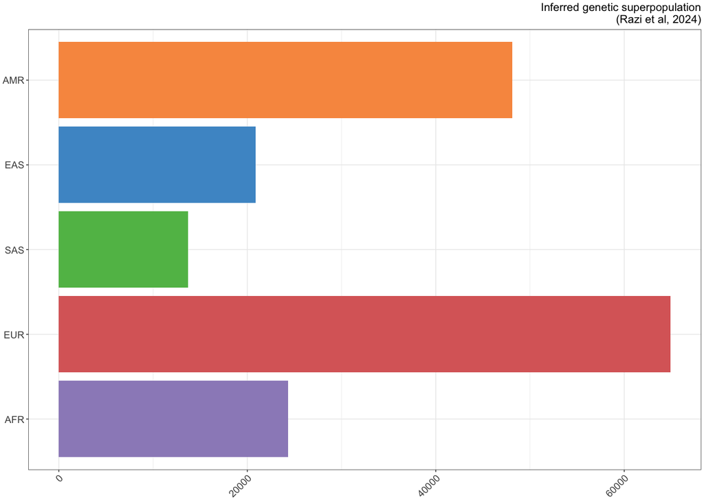

```r
kasperProp <- allSRAClean %>% count(pred_pop) %>% mutate(freq = n/sum(n))

kasperPlot <- ggplot(kasperProp, aes(x = fct_inorder(pred_pop), y = n, fill = pred_pop)) +
  geom_bar(stat="identity") +
  ggtitle("Inferred genetic superpopulation\n(Razi et al, 2024)") +
  xlab(NULL) +
  ylab(NULL) +
  coord_flip() +
  scale_fill_kasper() +
  theme(axis.text.x = element_text(angle = 45, hjust=1)) +
  theme(legend.position="none") +
  theme(plot.title = element_text(hjust = 1))

kasperPlot
```

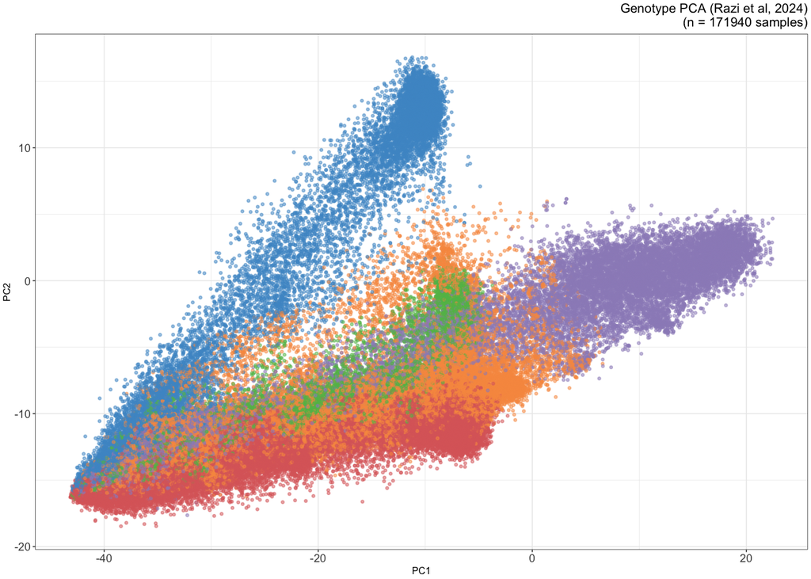

```r
ggsave("kasper_filtered_allsra_by_region.pdf", height=3, width=6)
ggsave("kasper_filtered_allsra_by_region.png", height=3, width=6)

# We also plot the PCA
kasperPCA <- ggplot(allSRAClean, aes(x = pc1, y = pc2, color=pred_pop )) +
  ggtitle(paste0("Genotype PCA (Razi et al, 2024)\n(n = ", nrow(allSRAClean), " samples)")) +
  geom_point(alpha = 0.5, size = 0.5) +
  ylab("PC2") +
  xlab("PC1") +
  theme(plot.title = element_text(hjust = 1)) +
  scale_color_kasper() +
  labs(color="Predicted\nSuperpopulation") +
  theme(legend.position = "none")
  # theme(legend.title.align = 1, legend.position = c(0.1,0.8), legend.background=element_blank()) +
  # theme(aspect.ratio=1)

kasperPCA
```